# Phân tích A/B Testing - Marketing Campaign

Phân tích Bootstrap & Permutation Test

2025-11-13

# Giới thiệu

Báo cáo này phân tích hiệu quả của chiến dịch quảng cáo (A/B testing) so sánh hai nhóm:

- **ad**: Người dùng xem quảng cáo
- **psa**: Người dùng chỉ xem thông báo công ích (Public Service Announcement)

Mục tiêu: Xác định xem việc xem quảng cáo có ảnh hưởng đến tỷ lệ chuyển đổi (conversion rate) hay không.

# 1. Data Cleaning & EDA

## 1.1 Đọc và làm sạch dữ liệu

```r
# Load các thư viện cần thiết
library(tidyverse)
library(janitor)
library(ggplot2)
library(boot)
library(infer)
library(RColorBrewer)
```

```r
# Đọc dữ liệu và làm sạch tên cột
data <- read.csv("C:/Users/lenovo/Downloads/marketing_AB.csv", header = TRUE) %>%
  clean_names()

# Xem cấu trúc dữ liệu
glimpse(data)
```

```
## Rows: 588,101
## Columns: 7
## $ x             <int> 0, 1, 2, 3, 4, 5, 6, 7, 8, 9, 10, 11, 12, 13, 14, 15, 16…
## $ user_id       <int> 1069124, 1119715, 1144181, 1435133, 1015700, 1137664, 11…
## $ test_group    <chr> "ad", "ad", "ad", "ad", "ad", "ad", "ad", "ad", "ad", "a…
## $ converted     <chr> "False", "False", "False", "False", "False", "False", "F…
## $ total_ads     <int> 130, 93, 21, 355, 276, 734, 264, 17, 21, 142, 209, 47, 6…
## $ most_ads_day  <chr> "Monday", "Tuesday", "Tuesday", "Tuesday", "Friday", "Sa…
## $ most_ads_hour <int> 20, 22, 18, 10, 14, 10, 13, 18, 19, 14, 11, 13, 20, 13, …
```

```r
# Chuyển đổi biến converted sang dạng numeric (1 = TRUE, 0 = FALSE)
data <- data |> mutate(
  test_group = as.factor(test_group),
  converted = ifelse(converted == "True", 1, 0)
)

# Hiển thị vài dòng đầu
head(data)
```

```
##   x user_id test_group converted total_ads most_ads_day most_ads_hour
## 1 0 1069124         ad         0       130       Monday            20
## 2 1 1119715         ad         0        93      Tuesday            22
## 3 2 1144181         ad         0        21      Tuesday            18
## 4 3 1435133         ad         0       355      Tuesday            10
## 5 4 1015700         ad         0       276       Friday            14
## 6 5 1137664         ad         0       734     Saturday            10
```

Các biến có trong dataset: `test_group`: gồm 2 nhóm (`ad`: có xem quảng cáo trên MXH, `psa`: chỉ xem thông báo trên MXH) `converted` : có mua hàng hay không (không mua: 0, có mua: 1) `total_ads` : tổng số quảng cáo xem được `most_ads_day`: xem nhiều nhất ngày nào `most_ads_hour`: xem nhiều nhất thời điểm nào

## 1.2 Tóm tắt dữ liệu

```r
# Tóm tắt chung
summary(data)
```

```
##        x             user_id        test_group     converted
##  Min.   :     0   Min.   : 900000   ad :564577   Min.   :0.00000
##  1st Qu.:147025   1st Qu.:1143190   psa: 23524   1st Qu.:0.00000
##  Median :294050   Median :1313725                Median :0.00000
##  Mean   :294050   Mean   :1310692                Mean   :0.02524
##  3rd Qu.:441075   3rd Qu.:1484088                3rd Qu.:0.00000
##  Max.   :588100   Max.   :1654483                Max.   :1.00000
##    total_ads       most_ads_day       most_ads_hour
##  Min.   :   1.00   Length:588101      Min.   : 0.00
##  1st Qu.:   4.00   Class :character   1st Qu.:11.00
##  Median :  13.00   Mode  :character   Median :14.00
##  Mean   :  24.82                      Mean   :14.47
##  3rd Qu.:  27.00                      3rd Qu.:18.00
##  Max.   :2065.00                      Max.   :23.00
```

```r
# Bảng phân phối test_group
table(data$test_group)
```

```
##
##     ad    psa
## 564577  23524
```

```r
# Bảng phân phối converted
table(data$converted)
```

```
##
##      0      1
## 573258  14843
```

```r
# Bảng chéo
table(data$test_group, data$converted)
```

```
##
##            0      1
##   ad  550154  14423
##   psa  23104    420
```

## 1.3 Số lượng quan sát mỗi nhóm

```r
# Đếm số quan sát trong mỗi nhóm
group_summary <- data %>%
  group_by(test_group) %>%
  summarise(
    n = n(),
    n_converted = sum(converted),
    conversion_rate = mean(converted)
  )

print(group_summary)
```

```
## # A tibble: 2 × 4
##   test_group      n n_converted conversion_rate
##   <fct>       <int>       <dbl>           <dbl>
## 1 ad         564577       14423          0.0255
## 2 psa         23524         420          0.0179
```

```r
# Tạo conversion_summary với conversion_pct để vẽ biểu đồ
conversion_summary <- group_summary %>%
  mutate(conversion_pct = round(conversion_rate * 100, 2))

# Tính chênh lệch quan sát (obs_diff) để dùng trong nhận xét
obs_diff <- conversion_summary %>%
  summarise(diff = conversion_rate[test_group == "ad"] -
                   conversion_rate[test_group == "psa"]) %>%
  pull(diff)
```

## 1.4 Biểu đồ tỷ lệ chuyển đổi

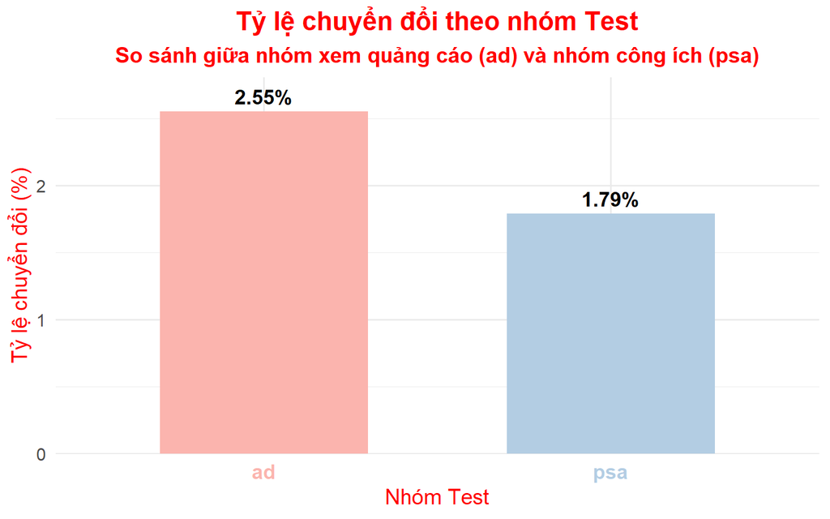

```r
# Vẽ biểu đồ thanh
pastel_colors <- RColorBrewer::brewer.pal(n = 2, name = "Pastel1")
names(pastel_colors) <- c("ad", "psa")
ggplot(conversion_summary, aes(x = test_group, y = conversion_pct, fill = test_group)) +
  geom_col(width = 0.6, alpha = 1) +
  geom_text(aes(label = paste0(conversion_pct, "%")),
            vjust = -0.5, size = 5, fontface = "bold") +
  scale_fill_manual(values = pastel_colors) +
  scale_y_continuous(expand = expansion(mult = c(0, 0.1))) +
  labs(
    title = "Tỷ lệ chuyển đổi theo nhóm Test",
    subtitle = "So sánh giữa nhóm xem quảng cáo (ad) và nhóm công ích (psa)",
    x = "Nhóm Test",
    y = "Tỷ lệ chuyển đổi (%)",
    fill = "Nhóm"
  ) +
  theme_minimal(base_size = 15) +
  theme(
    plot.title = element_text(hjust = 0.5, face = "bold", color= "red"),
    plot.subtitle = element_text(hjust = 0.5, face = "bold", color= "red"),
    axis.title.x = element_text(color = "red"),
    axis.title.y = element_text(color = "red"),
    axis.text.x = element_text(
      color = c(pastel_colors["ad"], pastel_colors["psa"]),
      face = "bold",
      size = 14
    ),
    legend.position = "none"
  )
```

**Nhận xét ban đầu:**

- Nhóm `ad` có tỷ lệ chuyển đổi là 2.55%
- Nhóm `psa` có tỷ lệ chuyển đổi là 1.79%
- Chênh lệch quan sát: 0.77%

# 2. Bootstrap Test

## 2.1 Phương pháp Bootstrap

Bootstrap là kỹ thuật lấy mẫu lại với thay thế (resampling with replacement) để kiểm định giả thuyết về sự khác biệt giữa hai tỷ lệ. Phương pháp này:

1. **Center data**: Dịch chuyển mỗi nhóm về trung bình 0 (giả định H₀ đúng)
2. **Resample**: Lấy mẫu lại từ mỗi nhóm đã center
3. **Tính statistic**: Tính chênh lệch mean(A) - mean(B) cho mỗi mẫu bootstrap
4. **So sánh**: Tính p-value bằng cách so sánh với chênh lệch quan sát

```r
# Hàm bootstrap kiểm định chênh lệch tỷ lệ
boot_diff_prop <- function(.data, x, g, R = 10000,
                           alternative = c("two.sided", "greater", "less"),
                           seed = NULL) {
  alternative <- match.arg(alternative)

  # --- Chuẩn bị dữ liệu ---
  df <- .data |> drop_na({{x}}, {{g}})
  xv <- df |> pull({{x}})
  gv <- df |> pull({{g}})
  g_levels <- levels(as.factor(gv))
  stopifnot(length(g_levels) == 2)

  A <- g_levels[1]
  B <- g_levels[2]

  nA <- sum(gv == A)
  nB <- sum(gv == B)

  # meanA - meanB (chênh lệch quan sát)
  t_obs <- mean(xv[gv == A]) - mean(xv[gv == B])

  # Center data về trung bình 0 (giả định H0 đúng)
  df_center <- df |>
    mutate(.g = as.factor({{g}}), .x = {{x}}) |>
    group_by(.g) |>
    mutate(.x_center = .x - mean(.x)) |>
    ungroup()

  pool_A <- df_center$.x_center[df_center$.g == A]
  pool_B <- df_center$.x_center[df_center$.g == B]

  # Bootstrap
  if (!is.null(seed)) set.seed(seed)
  t_star <- numeric(R)
  for (i in seq_len(R)) {
    samp_A <- sample(pool_A, size = nA, replace = TRUE)
    samp_B <- sample(pool_B, size = nB, replace = TRUE)
    t_star[i] <- mean(samp_A) - mean(samp_B)
  }

  # --- p-value ---
  pval <- switch(alternative,
                 "two.sided" = mean(abs(t_star) >= abs(t_obs)),
                 "greater"   = mean(t_star >= t_obs),
                 "less"      = mean(t_star <= t_obs))

  # --- Trả về kết quả ---
  list(summary = tibble(
       t_obs = t_obs,
       p_value = pval,
       alternative = alternative,
       n_A = nA,
       n_B = nB,
       rate_A = mean(xv[gv == A]),
       rate_B = mean(xv[gv == B]),
       A = A,
       B = B
     ),
     t_star = t_star)
}
```

## 2.2 Thực hiện Bootstrap Test

```r
# Chạy bootstrap với 10000 lần lặp
# Kiểm định một phía: H1: ad > psa (quảng cáo tốt hơn)
boot_out <- boot_diff_prop(data, x = converted, g = test_group,
                           R = 10000, alternative = "greater", seed = 2024)

# Hiển thị kết quả tóm tắt
print(boot_out$summary)
```

```
## # A tibble: 1 × 9
##     t_obs p_value alternative    n_A   n_B rate_A rate_B A     B
##     <dbl>   <dbl> <chr>        <int> <int>  <dbl>  <dbl> <chr> <chr>
## 1 0.00769       0 greater     564577 23524 0.0255 0.0179 ad    psa
```

```r
# Lưu các biến để dùng sau
bootstrap_diffs <- boot_out$t_star
obs_diff_boot <- boot_out$summary$t_obs
p_value_boot <- boot_out$summary$p_value
```

## 2.3 Biểu đồ phân phối Bootstrap

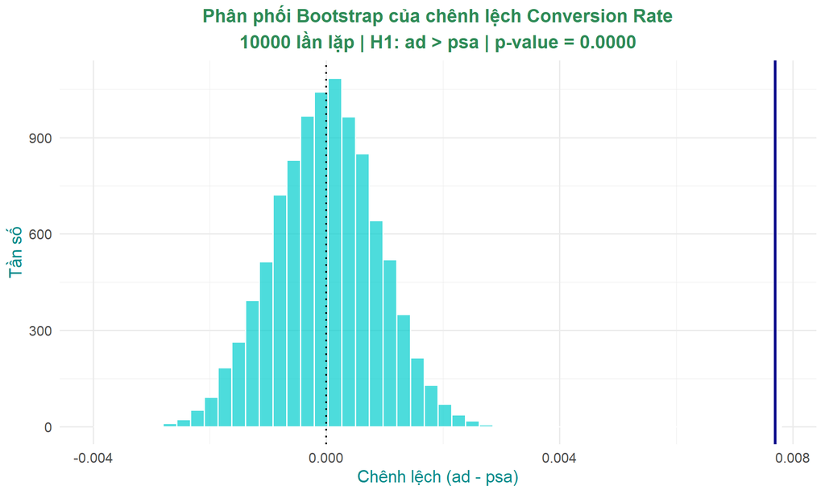

Phân phối Bootstrap của chênh lệch tỷ lệ chuyển đổi

```r
# Tạo dataframe cho ggplot
bootstrap_df <- data.frame(diff = bootstrap_diffs)

# Vẽ histogram
ggplot(bootstrap_df, aes(x = diff)) +
  geom_histogram(bins = 50, fill = "#00CDCD", alpha = 0.7, color = "white") +
  geom_vline(xintercept = obs_diff_boot, color = "blue4",
             linetype = "solid", linewidth = 1.2) +
  geom_vline(xintercept = 0, color = "black",
             linetype = "dotted", linewidth = 0.8) +
  labs(
    title = "Phân phối Bootstrap của chênh lệch Conversion Rate",
    subtitle = sprintf("10000 lần lặp | H1: ad > psa | p-value = %.4f", p_value_boot),
    x = "Chênh lệch (ad - psa)",
    y = "Tần số"
  ) +
  theme_minimal(base_size = 15) +
  theme(plot.title = element_text(hjust=0.5,color="#2E8B57", face = "bold", size = 16),
        plot.subtitle=element_text(hjust=0.5,color="#2E8B57", face = "bold", size = 16),
        axis.title.x = element_text(color = "#008B8B"),
        axis.title.y = element_text(color = "#008B8B"))
```

**Giải thích biểu đồ:**

- **Histogram xanh**: Phân phối bootstrap của chênh lệch dưới H₀ (dữ liệu đã center)
- **Đường xanh đậm liền liền**: Chênh lệch quan sát thực tế
- **Đường đen chấm**: Giá trị 0 (không có hiệu ứng)
- **p-value**: Xác suất quan sát được chênh lệch ≥ obs_diff nếu H₀ đúng

## 2.4 Kết luận Bootstrap

```r
alpha <- 0.05

cat("\nKẾT LUẬN BOOTSTRAP TEST:\n")
cat(sprintf("Chênh lệch quan sát: %.4f (%.2f%%)\n", obs_diff_boot, obs_diff_boot * 100))
cat(sprintf("p-value (H₁: ad > psa): %.4f\n", p_value_boot))
cat(sprintf("Mức ý nghĩa α: %.2f\n\n", alpha))

if (p_value_boot < alpha) {
  cat("p-value < α → BÁC BỎ giả thuyết H₀\n")
  cat("   → CÓ bằng chứng thống kê mạnh rằng quảng cáo (ad) tăng tỷ lệ chuyển đổi\n")
  cat("   → Nhóm ad có conversion rate cao hơn nhóm psa một cách có ý nghĩa\n")
} else {
  cat("p-value ≥ α → KHÔNG BÁC BỎ giả thuyết H₀\n")
  cat("   → Không có bằng chứng đủ mạnh về hiệu ứng của quảng cáo\n")
  cat("   → Chênh lệch có thể do ngẫu nhiên\n")
}
```

```
##
## KẾT LUẬN BOOTSTRAP TEST:
## Chênh lệch quan sát: 0.0077 (0.77%)
## p-value (H₁: ad > psa): 0.0000
## Mức ý nghĩa α: 0.05
##
## p-value < α → BÁC BỎ giả thuyết H₀
##    → CÓ bằng chứng thống kê mạnh rằng quảng cáo (ad) tăng tỷ lệ chuyển đổi
##    → Nhóm ad có conversion rate cao hơn nhóm psa một cách có ý nghĩa
```

# 3. Permutation Test

## 3.1 Phương pháp Permutation

Phương pháp: Hoán vị ngẫu nhiên nhãn nhóm, tính lại chênh lệch, so sánh với chênh lệch thực tế.

```r
# HÀM PERMUTATION TEST
perm_diff_prop <- function(.data, x, g, R = 10000,
                           alternative = c("two.sided","greater","less")){
  alternative <- match.arg(alternative)

  # Chuẩn bị dữ liệu
  df <- .data |> drop_na({{x}}, {{g}})
  xv <- df |> pull({{x}})
  gv <- df |> pull({{g}})
  g_levels <- levels(as.factor(gv))
  stopifnot(length(g_levels) == 2)

  # Chênh lệch quan sát (A - B theo thứ tự levels)
  A <- g_levels[1]
  B <- g_levels[2]
  obs <- mean(xv[gv == A]) - mean(xv[gv == B])

  # Hoán vị R lần
  n <- length(xv)
  nA <- sum(gv == A)
  nB <- sum(gv == B)
  perm_stats <- numeric(R)
  for(i in seq_len(R)){
    idx_a <- sample(x = 1:n, size = nA, replace = FALSE)
    idx_b <- setdiff(x = 1:n, y = idx_a)
    perm_stats[i] <- mean(xv[idx_a]) - mean(xv[idx_b])
  }

  # p-value theo đối thuyết
  pval <- switch(alternative,
                 "two.sided" = mean(abs(perm_stats) >= abs(obs)),
                 "greater"   = mean(perm_stats >= obs),
                 "less"      = mean(perm_stats <= obs))

  # Trả về kết quả
  list(
    summary = tibble(
      stat_obs = obs,
      p_value  = pval,
      alternative = alternative,
      n_A = nA,
      n_B = nB,
      rate_A = mean(xv[gv == A]),
      rate_B = mean(xv[gv == B]),
      A = A,
      B = B
    ),
    perm_stats = perm_stats
  )
}
```

## 3.2 Thực hiện Permutation Test

Permutation test (kiểm định hoán vị) kiểm tra giả thuyết:

- **H₀**: Không có sự khác biệt giữa hai nhóm (test_group không ảnh hưởng đến conversion)
- **H₁**: Nhóm ad có conversion rate **cao hơn** nhóm psa (ad > psa)

```r
# Chạy permutation test với 10000 lần hoán vị
# Kiểm định một phía: H1: ad > psa
perm_out <- perm_diff_prop(data, x = converted, g = test_group,
                           R = 10000, alternative = "greater")

# Hiển thị kết quả tóm tắt
cat("KẾT QUẢ PERMUTATION TEST\n")
cat(strrep("=", 50), "\n")
print(perm_out$summary)

# Lưu các biến để dùng sau
perm_diffs <- perm_out$perm_stats
obs_diff <- perm_out$summary$stat_obs
p_value <- perm_out$summary$p_value
```

```
## KẾT QUẢ PERMUTATION TEST
## ==================================================
## # A tibble: 1 × 9
##   stat_obs p_value alternative    n_A   n_B rate_A rate_B A     B
##      <dbl>   <dbl> <chr>        <int> <int>  <dbl>  <dbl> <chr> <chr>
## 1  0.00769       0 greater     564577 23524 0.0255 0.0179 ad    psa
```

## 3.3 Biểu đồ Permutation Distribution

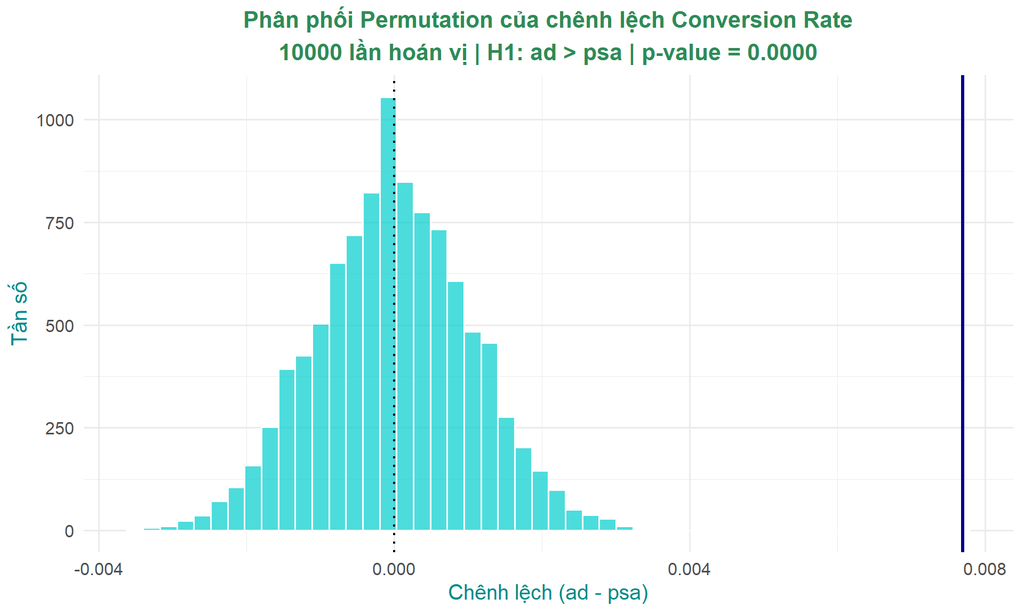

Phân phối hoán vị vs chênh lệch quan sát

```r
# Tạo dataframe
perm_df <- data.frame(diff = perm_diffs)

# Vẽ histogram
ggplot(perm_df, aes(x = diff)) +
  geom_histogram(bins = 50, fill = "#00CDCD", alpha = 0.7, color = "white") +
  geom_vline(xintercept = obs_diff_boot, color = "blue4",
             linetype = "solid", linewidth = 1.2) +
  geom_vline(xintercept = 0, color = "black",
             linetype = "dotted", linewidth = 0.8) +
  labs(
    title = "Phân phối Permutation của chênh lệch Conversion Rate",
    subtitle = sprintf("10000 lần hoán vị | H1: ad > psa | p-value = %.4f", p_value),
    x = "Chênh lệch (ad - psa)",
    y = "Tần số"
  ) +
  theme_minimal(base_size = 15) +
  theme(plot.title = element_text(hjust=0.5,color="#2E8B57", face = "bold", size = 16),
        plot.subtitle=element_text(hjust=0.5,color="#2E8B57", face = "bold", size = 16),
        axis.title.x = element_text(color = "#008B8B"),
        axis.title.y = element_text(color = "#008B8B"))
```

**Giải thích biểu đồ:**

- **Histogram xanh**: Phân phối chênh lệch khi H₀ đúng (không có hiệu ứng)
- **Đường xanh đậm**: Chênh lệch quan sát thực tế
- **Đường đen chấm**: Giá trị 0 (không có sự khác biệt)
- **p-value**: Tỷ lệ các hoán vị có chênh lệch ≥ chênh lệch quan sát (one-tailed test)

## 3.4 Kết luận Permutation Test

```r
alpha <- 0.05

cat("\nKẾT LUẬN PERMUTATION TEST:\n")
cat(sprintf("Chênh lệch quan sát: %.4f (%.2f%%)\n", obs_diff, obs_diff * 100))
cat(sprintf("p-value (H₁: ad > psa): %.4f\n", p_value))
cat(sprintf("Mức ý nghĩa α: %.2f\n\n", alpha))

if (p_value < alpha) {
  cat("p-value < α → BÁC BỎ giả thuyết H₀\n")
  cat("   → CÓ bằng chứng thống kê về sự khác biệt giữa hai nhóm\n")
  if (obs_diff > 0) {
    cat("   → Quảng cáo CÓ HIỆU QUẢ trong việc tăng conversion rate\n")
    cat("   → Nhóm ad có tỷ lệ chuyển đổi cao hơn nhóm psa một cách có ý nghĩa\n")
  } else {
    cat("   → Quảng cáo có hiệu ứng TIÊU CỰC lên conversion rate\n")
  }
} else {
  cat("p-value ≥ α → KHÔNG BÁC BỎ giả thuyết H₀\n")
  cat("   → Không có bằng chứng thống kê đủ mạnh\n")
  cat("   → Chênh lệch quan sát có thể do ngẫu nhiên\n")
}
```

```
##
## KẾT LUẬN PERMUTATION TEST:
## Chênh lệch quan sát: 0.0077 (0.77%)
## p-value (H₁: ad > psa): 0.0000
## Mức ý nghĩa α: 0.05
##
## p-value < α → BÁC BỎ giả thuyết H₀
##    → CÓ bằng chứng thống kê về sự khác biệt giữa hai nhóm
##    → Quảng cáo CÓ HIỆU QUẢ trong việc tăng conversion rate
##    → Nhóm ad có tỷ lệ chuyển đổi cao hơn nhóm psa một cách có ý nghĩa
```

# 4. Discussion & Tổng kết

## 4.1 So sánh hai phương pháp

```r
# Tạo bảng so sánh
comparison <- data.frame(
  Phương_pháp = c("Bootstrap (Centered)", "Permutation"),
  Mục_đích = c("Kiểm định giả thuyết (centered bootstrap)", "Kiểm định giả thuyết (hoán vị)"),
  Giả_định = c("H₀: không có sự khác biệt (center data)", "H₀: không có sự khác biệt"),
  Alternative = c("H₁: ad > psa (greater)", "H₁: ad > psa (greater)"),
  Kết_quả = c(
    sprintf("p = %.4f", p_value_boot),
    sprintf("p = %.4f", p_value)
  ),
  Kết_luận = c(
    ifelse(p_value_boot < alpha, "Bác bỏ H₀", "Không bác bỏ H₀"),
    ifelse(p_value < alpha, "Bác bỏ H₀", "Không bác bỏ H₀")
  )
)

knitr::kable(comparison, align = "l",
             caption = "Bảng so sánh Bootstrap (Centered) và Permutation Test")
```

Bảng so sánh Bootstrap (Centered) và Permutation Test

| Phương_pháp | Mục_đích | Giả_định | Alternative | Kết_quả | Kết_luận |
| --- | --- | --- | --- | --- | --- |
| Bootstrap (Centered) | Kiểm định giả thuyết (centered bootstrap) | H₀: không có sự khác biệt (center data) | H₁: ad > psa (greater) | p = 0.0000 | Bác bỏ H₀ |
| Permutation | Kiểm định giả thuyết (hoán vị) | H₀: không có sự khác biệt | H₁: ad > psa (greater) | p = 0.0000 | Bác bỏ H₀ |

## 4.2 Nhận xét chi tiết

### Bootstrap Test (Centered Bootstrap)

**Phương pháp:**

- Center dữ liệu mỗi nhóm về trung bình 0 (giả định H₀ đúng)
- Resample từ dữ liệu đã center
- Tính p-value bằng cách so sánh phân phối bootstrap với chênh lệch quan sát

**Ưu điểm:**

- Kiểm định chính xác cho giả thuyết H₀
- Không yêu cầu giả định phân phối
- Phân phối bootstrap xoay quanh 0 (dưới H₀)

**Kết quả:**

- p-value (H₁: ad > psa): 0
- Bác bỏ H₀ → Quảng cáo CÓ hiệu quả

### Permutation Test

**Ưu điểm:**

- Kiểm định chính xác (exact test) không cần giả định
- Đánh giá trực tiếp xác suất quan sát được kết quả dưới H₀
- Phù hợp với mẫu nhỏ

**Kết quả:**

- p-value: 0
- < 0.05 → Bác bỏ H₀, có hiệu ứng đáng kể

## 4.3 Kết luận tổng thể

```r
cat("\n" %+% strrep("=", 60) %+% "\n")
cat(" KẾT LUẬN CUỐI CÙNG\n")
cat(strrep("=", 60) %+% "\n\n")

cat(sprintf("Chênh lệch conversion rate quan sát: %.2f%%\n", obs_diff_boot * 100))
cat(sprintf("  (ad: %.2f%% vs psa: %.2f%%)\n\n",
            conversion_summary$conversion_pct[conversion_summary$test_group == "ad"],
            conversion_summary$conversion_pct[conversion_summary$test_group == "psa"]))

# Đánh giá ý nghĩa thống kê
bootstrap_sig <- p_value_boot < alpha
perm_sig <- p_value < alpha

cat("Ý nghĩa thống kê:\n")
cat(sprintf("  • Bootstrap Test (p = %.4f): %s\n",
            p_value_boot, ifelse(bootstrap_sig, "CÓ", "KHÔNG")))
cat(sprintf("  • Permutation Test (p = %.4f): %s\n",
            p_value, ifelse(perm_sig, "CÓ", "KHÔNG")))

if (bootstrap_sig && perm_sig) {
  cat("CẢ HAI phương pháp đều BÁC BỎ H₀.\n")
  cat("   → Kết luận MẠNH: Quảng cáo CÓ TÁC ĐỘNG TÍCH CỰC đến conversion rate.\n")
  cat("   → Nhóm xem quảng cáo (ad) có tỷ lệ chuyển đổi cao hơn có ý nghĩa thống kê.\n")
} else if (!bootstrap_sig && !perm_sig) {
  cat("CẢ HAI phương pháp đều KHÔNG BÁC BỎ H₀.\n")
  cat("   → Kết luận: Không đủ bằng chứng về hiệu ứng của quảng cáo.\n")
  cat("   → Chênh lệch quan sát có thể do ngẫu nhiên.\n")
} else {
  cat("Hai phương pháp cho kết quả KHÔNG NHẤT QUÁN.\n")
  cat("   → Cần xem xét thêm kích thước mẫu hoặc phân tích sâu hơn.\n")
}

cat("\n" %+% strrep("=", 60) %+% "\n")
```

```
##  KẾT LUẬN CUỐI CÙNG
## Chênh lệch conversion rate quan sát: 0.77%
##   (ad: 2.55% vs psa: 1.79%)
##
## Ý nghĩa thống kê:
##   • Bootstrap Test (p = 0.0000): CÓ
##   • Permutation Test (p = 0.0000): CÓ
## CẢ HAI phương pháp đều BÁC BỎ H₀.
##    → Kết luận MẠNH: Quảng cáo CÓ TÁC ĐỘNG TÍCH CỰC đến conversion rate.
##    → Nhóm xem quảng cáo (ad) có tỷ lệ chuyển đổi cao hơn có ý nghĩa thống kê.
```

## 4.4 Khuyến nghị

**Độ tin cậy:**

- Bootstrap và Permutation test đều là phương pháp robust, không yêu cầu giả định phân phối
- Cả hai đều phù hợp với dữ liệu nhị phân (converted: TRUE/FALSE)
- Với 10,000 lần lặp, kết quả có độ ổn định cao
- Bootstrap test sử dụng centered data để kiểm định H₀ chính xác

**Ứng dụng thực tế:**

1. **Bootstrap test (Centered)**: Kiểm định chính xác giả thuyết H₀ bằng cách center dữ liệu về 0
2. **Permutation test**: Kiểm định thuần túy, không có giả định về phân phối, phù hợp mẫu nhỏ
3. Kết hợp cả hai để có kết luận toàn diện và tin cậy hơn

**Hạn chế:**

- Chỉ phân tích conversion rate tổng thể, chưa xem xét:
  - Biến confounding (total_ads, most_ads_day, most_ads_hour)
  - Heterogeneous treatment effects (hiệu ứng khác nhau theo subgroup)
  - Time trends hoặc seasonal effects

**Bước tiếp theo:**

- Phân tích hồi quy logistic để kiểm soát các biến khác
- Segmentation analysis theo các nhóm người dùng
- Phân tích chi phí-lợi ích (cost-benefit analysis)